# ZRX

vineet

October 10, 2018

## R Markdown

@ authors: Vineet Vats (vxv180008) and Shruti Jaiswal (sxj170027)  
The Ethereum project is a blockchain platform, and our data comes from there. Although Ethereum started in 2015, most tokens have been created since 2016. As such, tokens have different starting dates, and their data starts from that initial date. Our Data has four Attributes: FromNodeId - Selling the Token,  
ToNodeId- Buying the Token,  
Unixdate- Data of transaction in UNIX time,  
TokenAmount- Token amount in the Transaction,

Here we are reading the data from the text file networkzrxTX.txt

```r
zrxtoken<-read.table(file="D:/networkzrxTX.txt",header=F,sep=" ")
summary(zrxtoken)
```

```
##        V1                V2                V3
##  Min.   :      4   Min.   :      2   Min.   :1.502e+09
##  1st Qu.:  44146   1st Qu.: 104236   1st Qu.:1.506e+09
##  Median :1746888   Median :1759164   Median :1.515e+09
##  Mean   :2523103   Mean   :3406770   Mean   :1.513e+09
##  3rd Qu.:2777458   3rd Qu.:5919106   3rd Qu.:1.519e+09
##  Max.   :9982269   Max.   :9982274   Max.   :1.526e+09
##        V4
##  Min.   :1.000e+00
##  1st Qu.:3.060e+20
##  Median :1.994e+21
##  Mean   :1.896e+27
##  3rd Qu.:8.000e+21
##  Max.   :1.400e+32
```

Here we will print the outliers.

```r
outliersvals <-zrxtoken[ which(zrxtoken$V4>=1e+27), ]
outliersvals
```

```
##             V1     V2         V3           V4
## 103704 8105805 198548 1516152231 1.400000e+32
## 104170 8105805 198548 1516170850 1.400000e+32
## 105821 8105805 198548 1516238722 1.400000e+32
## 105838 8105805 198548 1516239903 1.400000e+32
## 277325  121639 120427 1503087173 1.133408e+28
## 277327  121639 120427 1503087188 1.133408e+28
```

Excluding the above Outliers from the data and updating zrxtoken.

```r
zrxtoken <- zrxtoken[ which(zrxtoken$V4<=1e+27), ]
colnames(zrxtoken)<-c("FromNodeId","ToNodeId","Unixdate","TokenAmount")
summary(zrxtoken)
```

```
##    FromNodeId         ToNodeId          Unixdate
##  Min.   :      4   Min.   :      2   Min.   :1.502e+09
##  1st Qu.:  44146   1st Qu.: 104233   1st Qu.:1.506e+09
##  Median :1746888   Median :1759326   Median :1.515e+09
##  Mean   :2523044   Mean   :3406836   Mean   :1.513e+09
##  3rd Qu.:2777146   3rd Qu.:5919106   3rd Qu.:1.519e+09
##  Max.   :9982269   Max.   :9982274   Max.   :1.526e+09
##   TokenAmount
##  Min.   :1.000e+00
##  1st Qu.:3.060e+20
##  Median :1.994e+21
##  Mean   :2.430e+22
##  3rd Qu.:8.000e+21
##  Max.   :5.199e+26
```

Here we are taking the count of Users who are buying the token. We are Storing these attributes in a table CountOfBuy.

```r
Buytoken <-c(zrxtoken[,2])
CountOfBuy<-as.data.frame(table(Buytoken))
colnames(CountOfBuy)<-c("UserId","Frequency")
summary(CountOfBuy)
```

```
##      UserId         Frequency
##  2      :     1   Min.   :    1.000
##  4      :     1   1st Qu.:    1.000
##  5      :     1   Median :    1.000
##  6      :     1   Mean   :    2.682
##  7      :     1   3rd Qu.:    2.000
##  8      :     1   Max.   :22851.000
##  (Other):110138
```

Here we are taking the count of the frequency of the user buying token.This plot below shows that how many times a user buys a token.

```r
DoubleCountOfBuy<-as.data.frame(table(CountOfBuy$Frequency))
colnames(DoubleCountOfBuy)<-c("Count_buy","Count_user")
summary(DoubleCountOfBuy)
```

```
##    Count_buy     Count_user
##  1      :  1   Min.   :    1.0
##  2      :  1   1st Qu.:    1.0
##  3      :  1   Median :    2.0
##  4      :  1   Mean   :  688.4
##  5      :  1   3rd Qu.:    6.0
##  6      :  1   Max.   :73481.0
##  (Other):154
```

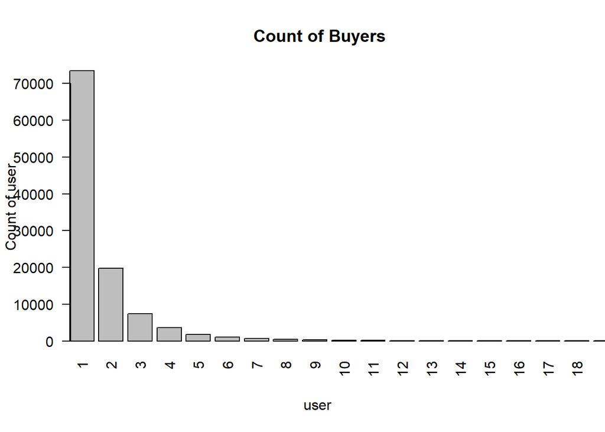

```r
barplot(DoubleCountOfBuy$Count_user,names.arg = DoubleCountOfBuy$Count_buy, las=2, xlab="user ", ylab="Count of user", xlim=c(1,20), col="grey", main = "Count of Buyers")
```

Here we are taking the count of Users who are Selling the token. We are Storing these attributes in a table CountOfSell.

```r
SellToken<-c(zrxtoken[,1])
CountOfSell<-as.data.frame(table(SellToken))
colnames(CountOfSell)<-c("UserId","Frequency")
summary(CountOfSell)
```

```
##      UserId        Frequency
##  4      :    1   Min.   :    1.000
##  5      :    1   1st Qu.:    1.000
##  6      :    1   Median :    1.000
##  7      :    1   Mean   :    3.981
##  8      :    1   3rd Qu.:    2.000
##  13     :    1   Max.   :25930.000
##  (Other):74193
```

Here we are taking the count of the frequency of the user Selling token.This plot shows that how many times a user Sells a token.

```r
DoubleCountOfSell<-as.data.frame(table(CountOfSell$Frequency))
colnames(DoubleCountOfSell)<-c("count_sell","count_user")
summary(DoubleCountOfSell)
```

```
##    count_sell    count_user
##  1      :  1   Min.   :    1.0
##  2      :  1   1st Qu.:    1.0
##  3      :  1   Median :    1.0
##  4      :  1   Mean   :  478.7
##  5      :  1   3rd Qu.:    5.0
##  6      :  1   Max.   :50734.0
##  (Other):149
```

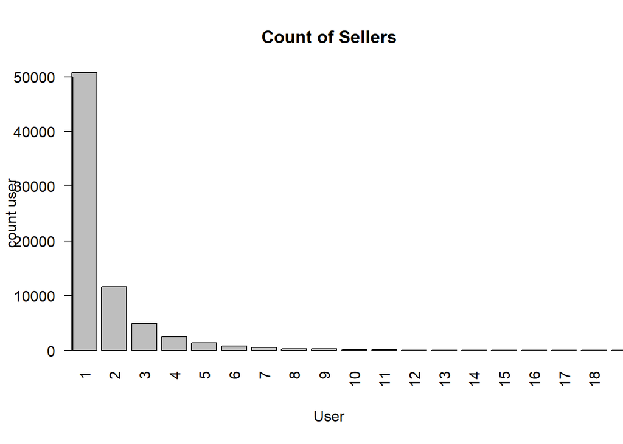

```r
barplot(DoubleCountOfSell$count_user,names.arg = DoubleCountOfSell$count_sell, las=2, xlab="User", ylab="count user", xlim=c(1,20), col="grey", offset(1), main = "Count of Sellers")
```

Fitting the poisson Distribution for Users who are Buying the token. The fitdistrplus package which we are using here is a general package that aims at helping the fit of univariate parametric distributions to censored or non-censored data.

```r
library(fitdistrplus)
```

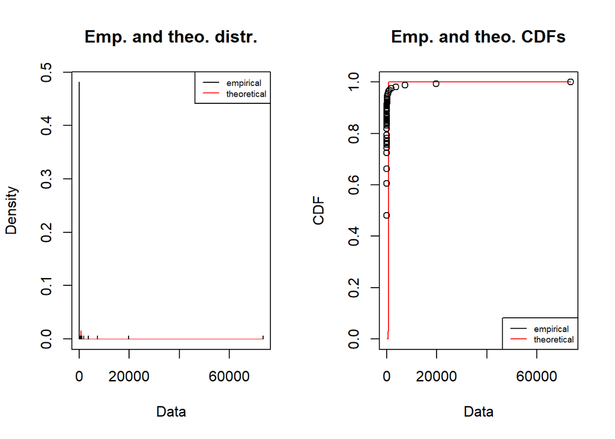

```r
No.pois<-fitdist(DoubleCountOfBuy[,2], distr = "pois")
plot(No.pois)
```

Fitting the poisson Distribution for Users who are selling their token.

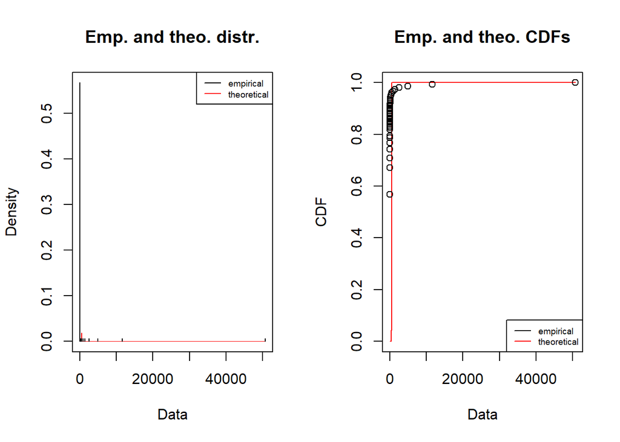

```r
No.pois<-fitdist(DoubleCountOfSell[,2], distr = "pois")
plot(No.pois)
```